# M280 Assignment2

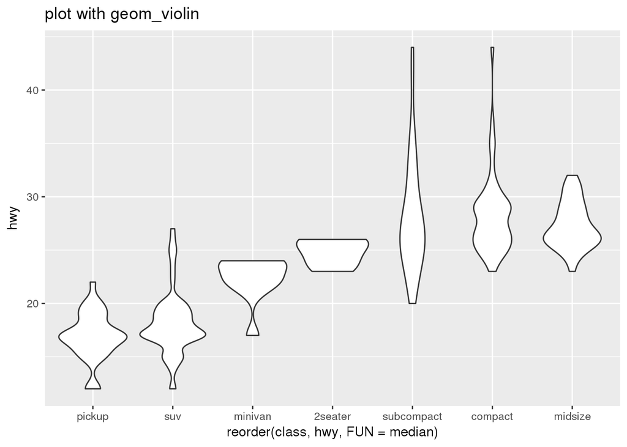

```r
# geom_violin plot
ggplot(data = mpg) +
  geom_violin(mapping = aes(x = reorder(class, hwy, FUN = median),
                                 y = hwy)) +
  labs(
    title = "plot with geom_violin"
  )
```

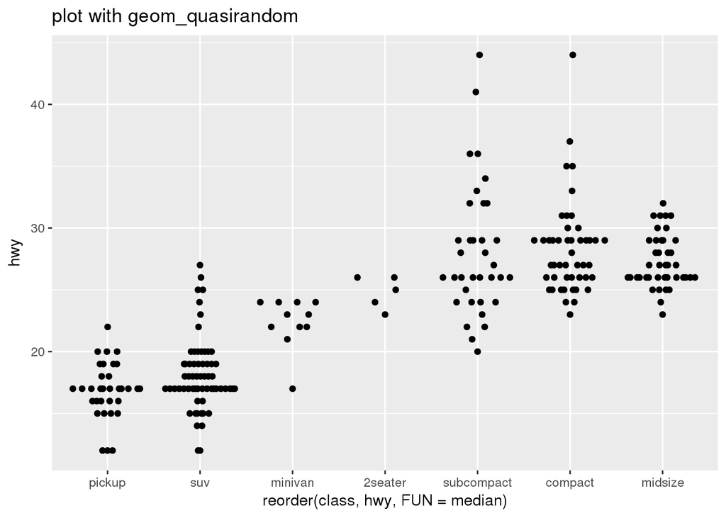

```r
# geom_quasirandom plot
ggplot(mpg) +
  geom_quasirandom(mapping = aes(x = reorder(class, hwy, FUN = median),
                           y = hwy)) +
  labs(
    title = "plot with geom_quasirandom"
  )
```

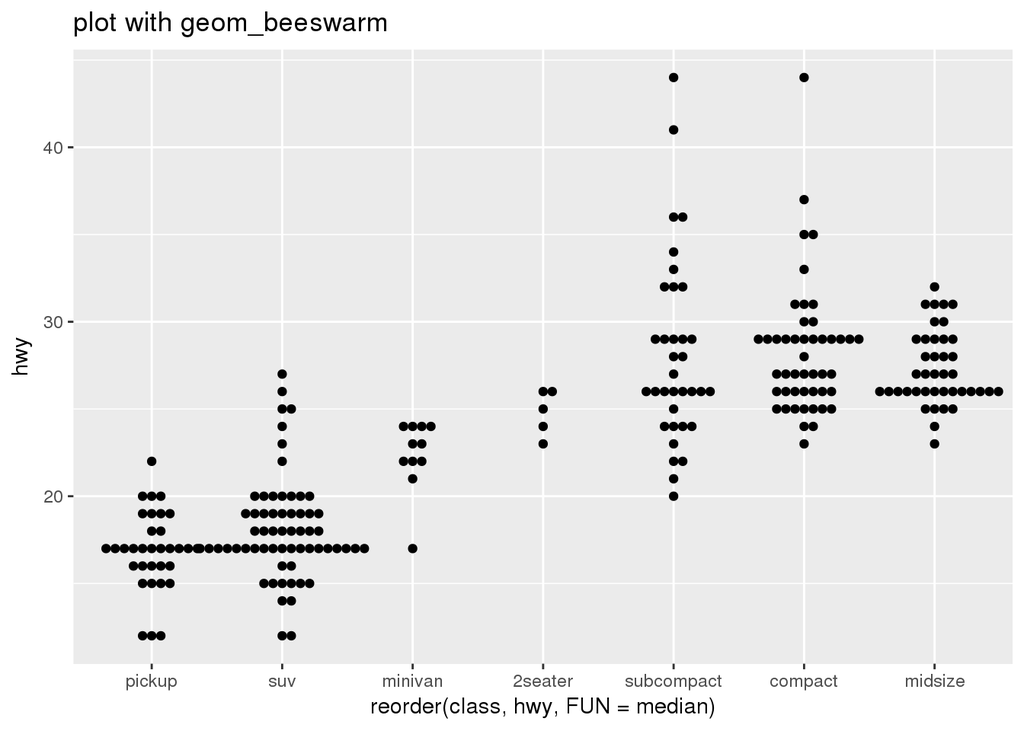

```r
# geom_beeswarm plot
ggplot(data = mpg) +
  geom_beeswarm(mapping = aes(x = reorder(class, hwy, FUN = median),
                                 y = hwy)) +
  labs(
    title = "plot with geom_beeswarm"
  )
```

- `geom_jitter()` helps to give a random relocation for overlapping points, which improves the visualization of the data. There is random gapping between poitns.
- `geom_qusirandom()` produces plots with random relocation for overlapping points just like jitter function, but it also gives a violin shape according to the density distribution. With the same hwy values, `geom_qusirandom()` arrange the points from the center line with random gapping. The random spacing further gives shape similar to the density distribution.
- `geom_beeswarm()` also creates plots with random relocation for overlapping points and violin shape. Comparing to `geom_qusirandom(),`geom_beeswarm()` arranges points with no gapping.

### 7.5.2.1

1. How could you rescale the count dataset above to more clearly show the distribution of cut within color, or color within cut?

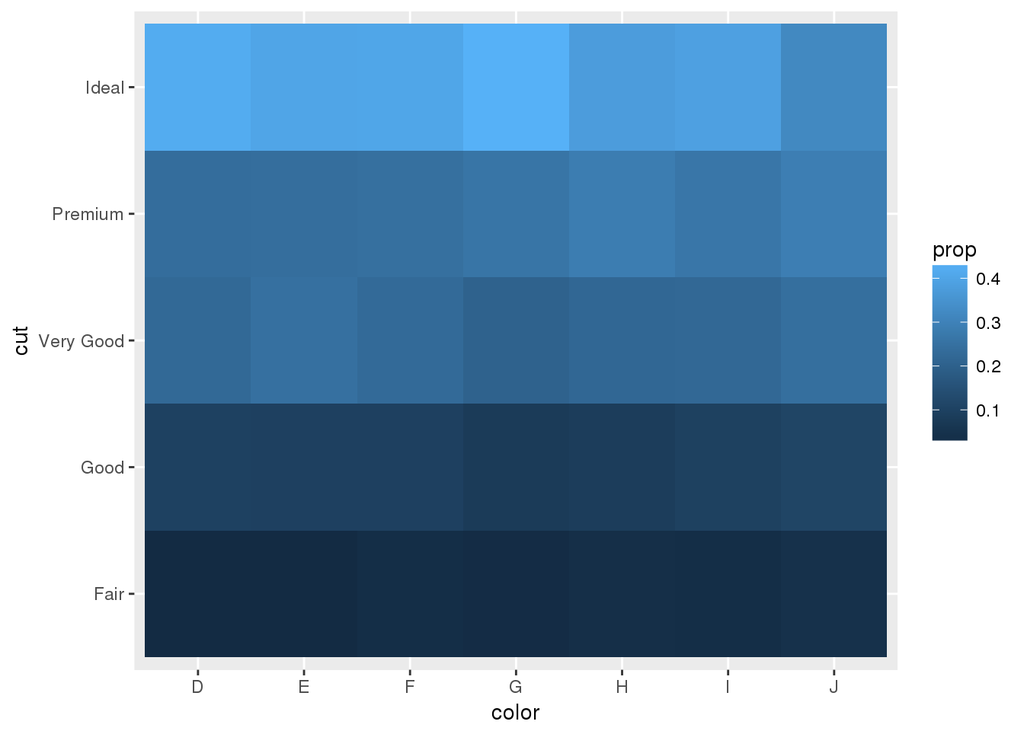

```r
# create new var prop = proportion of each cut within each color
# and produce the plot cut vs color
diamonds %>% count(color, cut) %>%
  group_by(color) %>%
  mutate(prop = n / sum(n)) %>%
  ggplot(mapping = aes(x = color, y = cut)) +
    geom_tile(mapping = aes(fill = prop)) +
    scale_color_grey()
```

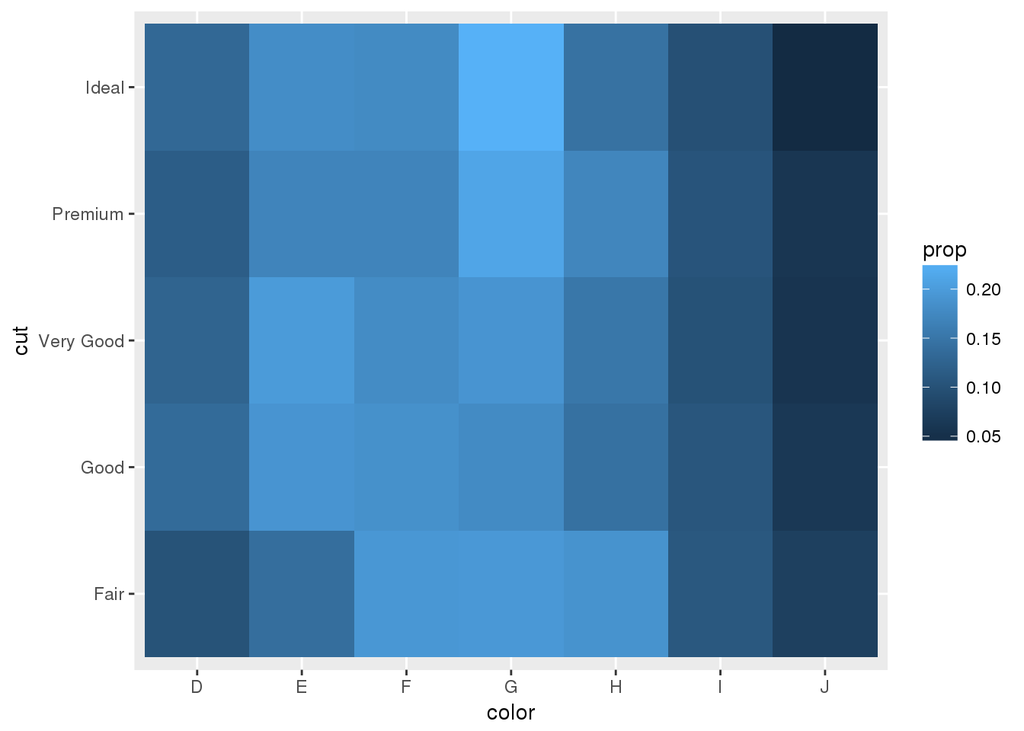

```r
# create new var prop = proportion of each color within each cut
# and produce the plot cut vs color
diamonds %>% count(color, cut) %>%
  group_by(cut) %>%
  mutate(prop = n / sum(n)) %>%
  ggplot(mapping = aes(x = color, y = cut)) +
    geom_tile(mapping = aes(fill = prop)) +
    scale_color_grey()
```

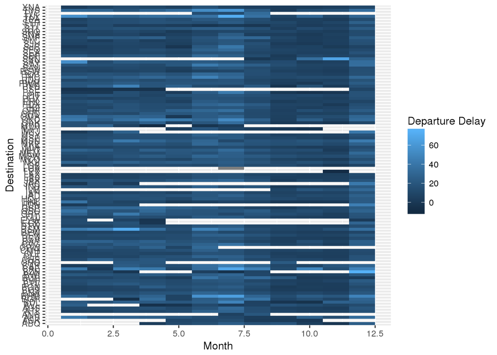

```r
flights %>%
  group_by(month, dest) %>%
  summarise(avg.dep.delay = mean(dep_delay, na.rm = TRUE)) %>%
  ggplot() +
    geom_tile(aes(x = month, y = dest, fill = avg.dep.delay)) +
    labs(x = "Month",
         y = "Destination",
         fill = "Departure Delay")
```

- There are too many destinations in the data, which makes the y labels squeeze together and is hard to read. It also increases the number of tiles in the graph, which makes it hard to interpret each tile. It is also hard to distinguish from light blue to dark blue. Using more distinguishable color may be a better choice. Also, there are blank tiles in the graph, which indicate the missing values for average flight. This is caused by no flight departed from the airport at certain month. The x label for month should be integers.